# FYP_Pilot2_dataCleaning

Bernice Cheung

4/22/2020

# Load and prep the data

Raw data was directly downloaded from Qualtric on 04/22/20. A filter that only includes particpants who consented and completed the survey was applied prior to downloading it. 206 participants are included in this raw dataset.

```r
# load raw data
rawDf <- read.csv("./input/Goal Representation-FYP_April 22, 2020_22.39.csv",stringsAsFactors = F)
```

Organize raw dataframe

```r
# delete the first two rows of labels and questions
rawDf_cleaned <- rawDf[-c(1,2),]

# write the data without the 2 rows
write.csv(rawDf_cleaned,"./output/raw_clean.csv",row.names = F)

# reload the raw cleaned dataframe
rawDf_cleaned <- read.csv("./output/raw_clean.csv",stringsAsFactors = F)
```

Transform and generate variables

```r
# convert the duration in seconds to minutes
rawDf_cleaned$Duration <- rawDf_cleaned$Duration..in.seconds./60

# Generate the number of goals subject listed
list_df <- rawDf_cleaned %>% dplyr::select(contains("goal_list"))
rawDf_cleaned$listNum <- rowSums(list_df != "")

# Generate the duration per goal
rawDf_cleaned$timePerGoal <- rawDf_cleaned$Duration/rawDf_cleaned$listNum
```

Transform the data relavent to goal rating into a long format dataframe

```r
# subset goal rating related dataset
goalRating <- subset(rawDf_cleaned, select = G1_1:G35_5)
goalRating <- bind_cols(goalRating, rawDf_cleaned[,c("id","listNum", "total_goal")])

# transform the dataset to long format
goalRating_long <- goalRating %>% gather(variable, rating, G1_1:G35_5)

# transform existing question number to the corresponding variable name and goal number

goalRating_long$goal <- str_sub(goalRating_long$variable,-1,-1)

variableName <- c("construal_level", "temporal_duration", "frequency", "specificity", "end_state_specificity", "approach_avoidance", "attainment_maintenance", "measurability", "importance", "meaningfulness", "instrumentality", "connectedness", "attractiveness_achievement", "attractiveness_progress", "social_desirability", "difficulty", "affordance", "attainability", "clarity", "control", "external_motivation", "introjected_motivation", "identified_motivation", "intrinsic_motivation", "ought_motivation", "ideal_motivation", "basic_needs", "commonality", "visibility", "external_importance")
progressName <- c("commitment", "urgency", "effort", "advancement", "initial_time")
nameList <- c(variableName, progressName)
questionNum <- paste0("G", 1:35, "_")

nameDf <- data.frame("question_number" = questionNum,
                     "variable_name" = nameList)

for (idx in 1: nrow(nameDf)){
  goalRating_long$variable[grepl(nameDf$question_number[idx],goalRating_long$variable)] <- as.character(nameDf$variable_name[idx])
}

# get rid off the NAs for questions corresponding to goals that the subjects didn't list
goalRating_long <- goalRating_long[goalRating_long$goal <= goalRating_long$listNum,]
```

# Excluding participants

### Exclusion Criteria 1:Task Duration

Descriptive and histogram on timePerGoal (task duration / number of listed goals) for all participants

```r
# Descriptive on duration
describe(rawDf_cleaned$timePerGoal)
```

```
##    vars   n  mean     sd median trimmed  mad  min     max  range skew kurtosis
## X1    1 206 39.72 179.91  10.31   11.15 4.68 1.56 2178.66 2177.1 9.17    97.84
##       se
## X1 12.54
```

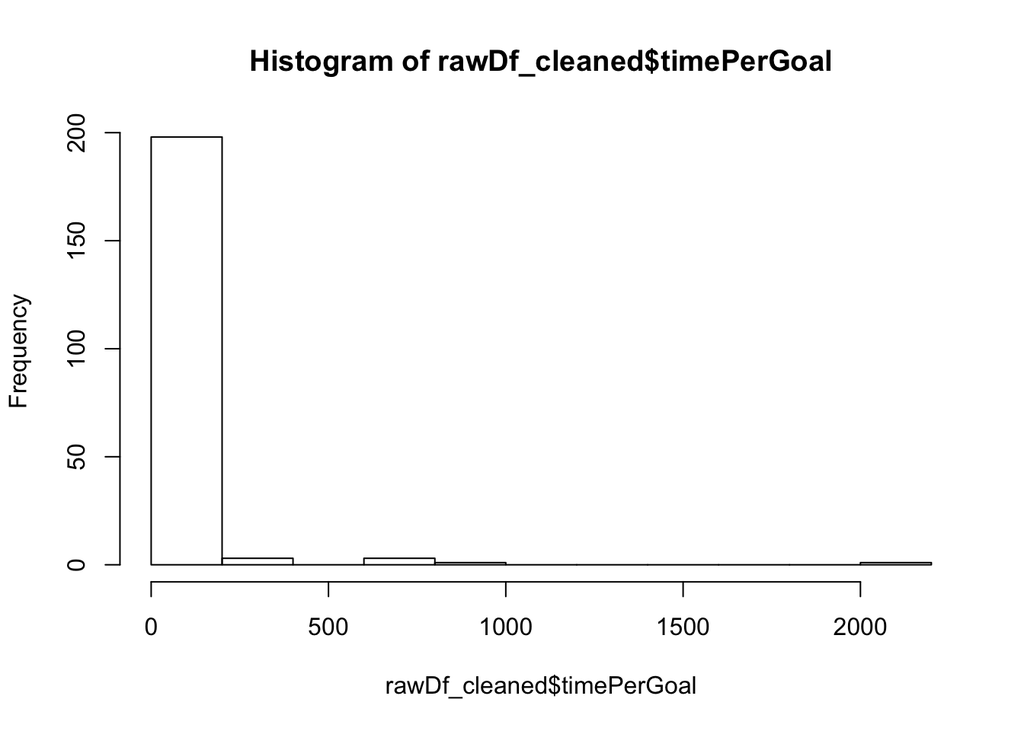

```r
# Histograme
hist(rawDf_cleaned$timePerGoal)
```

Subjects who spend more than 2.5 hours to complete the study is excluded from the histogram in order to better visualized the lower end of the distribution (12 totoal).

Descriptive after excluding participants with long duration

```r
# subjects who used more than 2.5 hours to complte the task
id_durationLong <- rawDf_cleaned[rawDf_cleaned$Duration > 150,c("id", "Duration", "listNum")]

# re-do descriptive after removing those participants
colors <- c(rep("red",4), rep("orange",26))

rawDf_cleaned %>% filter(!id %in% id_durationLong$id) %>% dplyr::select(timePerGoal) %>% describe()
```

```
##    vars   n  mean  sd median trimmed  mad  min   max range skew kurtosis   se
## X1    1 194 11.17 5.9   9.83   10.43 4.11 1.56 34.23 32.67 1.52     3.06 0.42
```

Subjects with extreme values at the lower end are identified by visual inspection of the histogram. In the pilot dataset, subjects who spent less than 5 minutes per goal are excluded (marked in red on the histogram).

16 participants are subjected to exclusion based on this criteria

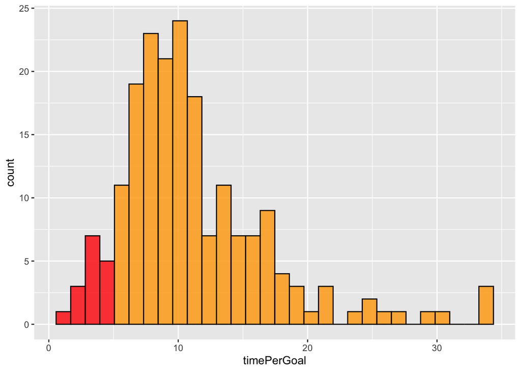

```r
rawDf_cleaned %>% filter(!id %in% id_durationLong$id) %>% ggplot(aes(timePerGoal)) + geom_histogram(fill   = colors,
                   colour = "black",
                   alpha  = .8)
```

```r
# subjects who used less then 5 minutes per goal
id_durationShort <- rawDf_cleaned[rawDf_cleaned$timePerGoal <5,c("id", "Duration","timePerGoal", "listNum")]
```

### Exclusion Criteria 2: Attention check questions

We set 3 attention check questions. One is at the end of the goal rating section, two are embeded within standardized individual difference measures. We exclude subjects who missed at least 1 attention check question in the individual difference measures.

35 participants are subjected to exclusion based on this criteria

```r
# extract attention check questions
checkDf <- rawDf_cleaned[,grepl("check",names(rawDf_cleaned))]
checkDf$id <- rawDf_cleaned$id

# compare to correct answers
checkDf <- checkDf %>% mutate(corr_1 = check1 =="17")
checkDf <- checkDf %>% mutate(corr_2 = check2 ==3)
checkDf <- checkDf %>% mutate(corr_3 = check3 ==5)
checkDf$corr_sum <- rowSums(checkDf[,c("corr_1","corr_2","corr_3")],na.rm = T)

# extract subject id with either got the second or the third attention question wrong
id_missCheck <- checkDf %>% filter(corr_2 == FALSE | corr_3 == FALSE)

# combine dataset
rawDf_cleaned <- left_join(rawDf_cleaned, checkDf, by = "id")
```

### Exclusion Criteria 3: Repetitive responses

We extract sequence of identical numeric responses acrosss all questions and measure for each subject, and plot the maximal length of the sequence in a histogram. Outliers are visually inspected and excluded. For the pilot study, subjects who had more than 20 repetitive responsese are excluded (marked in red on the histogram).

7 participants are subjected to exclusion based on this criteria

```r
# extract columns with likert scale ratings
ratingDf <- dplyr::select(rawDf_cleaned, "G1_1":"LET6")

# extract the max number of repetitive response in a row
variation <- apply(ratingDf,1,function(x) rle(x))
variation.length <-unlist(lapply(variation,function(x) max(x$lengths)))
describe(variation.length)
```

```
##    vars   n mean   sd median trimmed  mad min max range skew kurtosis   se
## X1    1 206 8.51 8.08      7    7.01 2.97   3  76    73 5.09    32.07 0.56
```

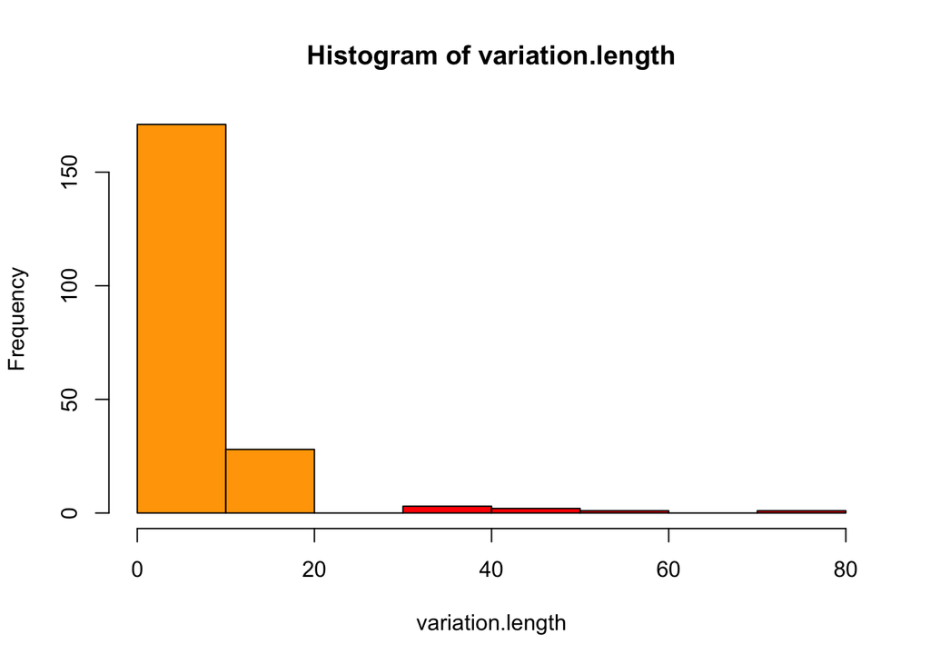

```r
hist(variation.length, col = c(rep("orange", 3), rep("red", 5)))
```

```r
rawDf_cleaned$invariance_max <- variation.length

# extract subject id who has more than 20 repetitive response in a row
id_invariance <- rawDf_cleaned$id[variation.length > 20]
```

### Exclusion Criteria 4: Missing data in the goal rating session

Because subjects listed various number of goals, the total number of questions in the goal rating session for a given subject is calculated by the number of goal listed times the number of question per goal (35 questions). The porpotion of missing data in the goal rating session is then calculated and outliers are visual inspected through a histogram. In the pilot dataset, subjects who missed 10% is excluded (marked in red on the histogram)

3 participants are subjected to exclusion based on this criteria

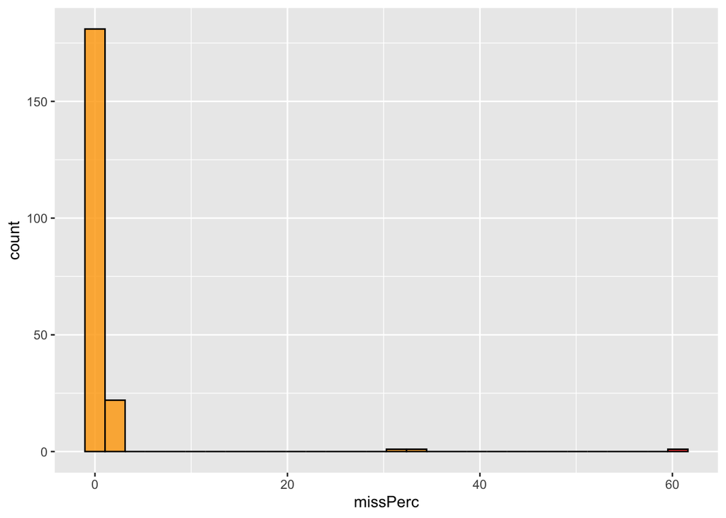

```r
# calculate the percentage of missing data
missDf <- goalRating_long %>%
  group_by(id) %>%
  summarise(missNum = sum(is.na(rating)),
            totalNum = mean(listNum) * 35) %>% #the total number of data per subject depends on the number of goals they listed
  mutate(missPerc = (missNum/totalNum * 100))

# record the missing proportion
rawDf_cleaned$missPerc <- missDf$missPerc

# visualize the persentage of missing data
color <- c(rep("orange", 29), "red")
missDf %>% ggplot(aes(missPerc)) +
  geom_histogram(fill= color,
                   colour = "black",
                   alpha  = .8)
```

```r
# extract subject id who missed more than 10%
id_missRate <- missDf %>% filter(missPerc >10)
```

### Organize subjects who are excluded

Exclude subjects if they were identified based on any of the exclusion Criteria. Based on all 4 exclusion criteria, 38 participants should be excluded.

```r
# aggregate id and relevent info.
id_candidate <- unique(c(id_durationShort$id, id_missCheck$id, id_invariance, id_missRate$id))
candidateDf <- rawDf_cleaned %>% dplyr::select(c("id", "Duration", "timePerGoal","listNum", "corr_sum", "invariance_max", "missPerc")) %>% filter(id %in% id_candidate)
```

If we don’t exclude participants based on attention check questions, 20 participants should be excluded. Their info. relevant to exclusion is listed below.  
[Duration: number of minute used to complete the entire survey; listNum: number of goals being rated; corr_sum: number of correct attention check question; invariance_max: the max number of invariance response; missPerc: percent of missing data in the goal rating portion].

```r
# aggregate id and relevent info.
id_candidate2 <- unique(c(id_durationShort$id, id_invariance, id_missRate$id))

candidateDf2 <- rawDf_cleaned %>% dplyr::select(c("id", "Duration","timePerGoal", "listNum", "corr_sum", "invariance_max", "missPerc")) %>% filter(id %in% id_candidate2)

candidateDf2
```

```
##       id Duration timePerGoal listNum corr_sum invariance_max  missPerc
## 1  42344 20.60000    4.120000       5        3             10 0.0000000
## 2  46323 10.86667    2.173333       5        1              8 0.0000000
## 3  48992 13.08333    2.616667       5        0             44 0.0000000
## 4  49327 18.73333    3.746667       5        1             44 0.0000000
## 5  49418 19.10000    4.775000       4        1              4 0.0000000
## 6  47707 26.35000    8.783333       3        1             31 0.0000000
## 7  49465 20.40000    4.080000       5        2              5 0.0000000
## 8  49436 22.51667    4.503333       5        0              5 0.7142857
## 9  49588 17.53333    3.506667       5        0              5 0.0000000
## 10 47817 11.53333   11.533333       1        0             12 0.0000000
## 11 45940 15.70000    3.925000       4        2              4 0.0000000
## 12 49428 54.30000   10.860000       5        3              7 0.0000000
## 13 48869 22.86667    4.573333       5        2             15 0.0000000
## 14 49519 18.96667    3.793333       5        0             19 1.7142857
## 15 49155 15.03333    3.006667       5        0             15 0.0000000
## 16 48987 18.21667    3.643333       5        1             76 0.0000000
## 17 49746  7.80000    1.560000       5        0             31 0.0000000
## 18 49344 64.98333   21.661111       3        2             58 0.0000000
## 19 44873 14.15000    2.830000       5        0             32 0.9523810
## 20 48237 11.20000    2.240000       5        0             13 0.0000000
```

Below is the relevant info for those who are subject to exclusions only based on attention check question.

```r
# check relavent info. for those who are subject to exclusion only based on attention check qeustion
candidateDf %>%
  filter(!id %in% candidateDf2$id)
```

```
##       id    Duration timePerGoal listNum corr_sum invariance_max  missPerc
## 1  49236   45.816667   15.272222       3        0              4 0.0000000
## 2  46656   66.816667   13.363333       5        2              5 0.0000000
## 3  48731   46.266667    9.253333       5        1              9 0.0000000
## 4  45739   57.866667   19.288889       3        1              9 0.0000000
## 5  47996   33.933333   33.933333       1        1              6 1.9047619
## 6  48772   10.950000   10.950000       1        0             17 0.5714286
## 7  49177   83.766667   16.753333       5        2              5 0.0000000
## 8  46584   21.900000    7.300000       3        2             15 0.0000000
## 9  46468 1095.033333  219.006667       5        0              3 0.0000000
## 10 49061   30.016667    6.003333       5        1             18 0.0000000
## 11 46971   36.950000    7.390000       5        2              7 0.0000000
## 12 49821   54.400000   10.880000       5        0              6 0.5714286
## 13 48512   45.050000    9.010000       5        1              7 0.0000000
## 14 49665   55.900000   11.180000       5        1             13 0.0000000
## 15 49648   35.333333   11.777778       3        1              5 0.0000000
## 16 49449  133.066667   26.613333       5        2              7 0.0000000
## 17 49894    7.566667    7.566667       1        0             11 0.0000000
## 18 49941   26.216667    5.243333       5        1             18 0.0000000
```

Below is the relevant info for those who are subject to exclusions only because their timePerGoal is between 4-5 minutes. Only 2 people fit this condition, indicating the cut off line is reasonable. I even extend the condition to 3-5 minutes, and still only these 2 people fit.

```r
duration4_id <- id_durationShort %>%
  filter(timePerGoal >=4)

candidateDf %>%
  filter(id %in% duration4_id$id) %>%
  filter(!id %in% id_missCheck$id)
```

```
##      id Duration timePerGoal listNum corr_sum invariance_max missPerc
## 1 42344 20.60000    4.120000       5        3             10        0
## 2 48869 22.86667    4.573333       5        2             15        0
```